#### Instructions:

For all questions after 10th, Please only use the data specified in the note given just below the question You need to add answers in the same file i.e. PDS_UberDriveProject_Questions.ipynb' and rename that file as 'Name_Date.ipynb'.You can mention the date on which you will be uploading/submitting the file.For e.g. if you plan to submit your assignment on 1st January 2021, you can rename the file as 'STUDENTNAME_01-Jan-2021'

# Load the necessary libraries. Import and load the dataset with a name uber_drives .

```python
import numpy as np
import pandas as pd
import seaborn as sns
import matplotlib.pyplot as plt
from warnings import filterwarnings
filterwarnings("ignore")
```

```python
# Get the Data
uber_drives = pd.read_csv('uberdrives.csv')
```

## Q1. Show the last 10 records of the dataset. (2 point)

```python
uber_drives.tail(10)
```

|  | START_DATE* | END_DATE* | CATEGORY* | START* | STOP* | MILES* | PURPOSE* |
| --- | --- | --- | --- | --- | --- | --- | --- |
| 1145 | 12/30/2016 10:15 | 12/30/2016 10:33 | Business | Karachi | Karachi | 2.8 | Errand/Supplies |
| 1146 | 12/30/2016 11:31 | 12/30/2016 11:56 | Business | Karachi | Karachi | 2.9 | Errand/Supplies |
| 1147 | 12/30/2016 15:41 | 12/30/2016 16:03 | Business | Karachi | Karachi | 4.6 | Errand/Supplies |
| 1148 | 12/30/2016 16:45 | 12/30/2016 17:08 | Business | Karachi | Karachi | 4.6 | Meeting |
| 1149 | 12/30/2016 23:06 | 12/30/2016 23:10 | Business | Karachi | Karachi | 0.8 | Customer Visit |
| 1150 | 12/31/2016 1:07 | 12/31/2016 1:14 | Business | Karachi | Karachi | 0.7 | Meeting |
| 1151 | 12/31/2016 13:24 | 12/31/2016 13:42 | Business | Karachi | Unknown Location | 3.9 | Temporary Site |
| 1152 | 12/31/2016 15:03 | 12/31/2016 15:38 | Business | Unknown Location | Unknown Location | 16.2 | Meeting |
| 1153 | 12/31/2016 21:32 | 12/31/2016 21:50 | Business | Katunayake | Gampaha | 6.4 | Temporary Site |
| 1154 | 12/31/2016 22:08 | 12/31/2016 23:51 | Business | Gampaha | Ilukwatta | 48.2 | Temporary Site |

## Q2. Show the first 10 records of the dataset. (2 points)

```python
uber_drives.head(10)
```

|  | START_DATE* | END_DATE* | CATEGORY* | START* | STOP* | MILES* | PURPOSE* |
| --- | --- | --- | --- | --- | --- | --- | --- |
| 0 | 01-01-2016 21:11 | 01-01-2016 21:17 | Business | Fort Pierce | Fort Pierce | 5.1 | Meal/Entertain |
| 1 | 01-02-2016 01:25 | 01-02-2016 01:37 | Business | Fort Pierce | Fort Pierce | 5.0 | NaN |
| 2 | 01-02-2016 20:25 | 01-02-2016 20:38 | Business | Fort Pierce | Fort Pierce | 4.8 | Errand/Supplies |
| 3 | 01-05-2016 17:31 | 01-05-2016 17:45 | Business | Fort Pierce | Fort Pierce | 4.7 | Meeting |
| 4 | 01-06-2016 14:42 | 01-06-2016 15:49 | Business | Fort Pierce | West Palm Beach | 63.7 | Customer Visit |
| 5 | 01-06-2016 17:15 | 01-06-2016 17:19 | Business | West Palm Beach | West Palm Beach | 4.3 | Meal/Entertain |
| 6 | 01-06-2016 17:30 | 01-06-2016 17:35 | Business | West Palm Beach | Palm Beach | 7.1 | Meeting |
| 7 | 01-07-2016 13:27 | 01-07-2016 13:33 | Business | Cary | Cary | 0.8 | Meeting |
| 8 | 01-10-2016 08:05 | 01-10-2016 08:25 | Business | Cary | Morrisville | 8.3 | Meeting |
| 9 | 01-10-2016 12:17 | 01-10-2016 12:44 | Business | Jamaica | New York | 16.5 | Customer Visit |

## Q3. Show the dimension(number of rows and columns) of the dataset. (2 points)

```python
#It returns a tuple of rows and columns
print("The dimension of the dataset is: ",uber_drives.shape)
```

```
The dimension of the dataset is:  (1155, 7)
```

## Q4. Show the size (Total number of elements) of the dataset. (2 points)

```python
#It returns the multiplication of numbers of rows and columns in a dataframe.
print("The size of the dataset is: ",uber_drives.size)
```

```
The size of the dataset is:  8085
```

## Q5. Display the information about all the variables of the data set. What can you infer from the output?(1 +2 points)

#### Hint: Information includes - Total number of columns,variable data-types, number of non-null values in a variable, and usage

```python
uber_drives.info()

#info() function is used to print concise summary of a dataframe.
#we can get the information of data types, number of non-null values for each variable and memmory usage of dataframe from the info() function
#
```

```
<class 'pandas.core.frame.DataFrame'>
RangeIndex: 1155 entries, 0 to 1154
Data columns (total 7 columns):
 #   Column       Non-Null Count  Dtype
---  ------       --------------  -----
 0   START_DATE*  1155 non-null   object
 1   END_DATE*    1155 non-null   object
 2   CATEGORY*    1155 non-null   object
 3   START*       1155 non-null   object
 4   STOP*        1155 non-null   object
 5   MILES*       1155 non-null   float64
 6   PURPOSE*     653 non-null    object
dtypes: float64(1), object(6)
memory usage: 63.3+ KB
```

## Q6. Check for missing values. (2 points)

#### Note: Output should contain only one boolean value

```python
uber_drives.isnull().values.any()
```

```
True
```

## Q7. How many missing values are present in the entire dataset? (2 points)

```python
print("The number of missing values present in entire dataset:",uber_drives.isnull().values.sum())
```

```
The number of missing values present in entire dataset: 502
```

## Q8. Get the summary of the original data. (2 points).

#### Hint: Summary includes- Count,Mean, Std, Min, 25%,50%,75% and max

```python
uber_drives.describe()
```

|  | MILES* |
| --- | --- |
| count | 1155.000000 |
| mean | 10.566840 |
| std | 21.579106 |
| min | 0.500000 |
| 25% | 2.900000 |
| 50% | 6.000000 |
| 75% | 10.400000 |
| max | 310.300000 |

## Q9. Drop the missing values and store the data in a new dataframe (name it"df") (2-points)

#### Note: Dataframe "df" will not contain any missing value

```python
df=uber_drives.dropna()
df
```

|  | START_DATE* | END_DATE* | CATEGORY* | START* | STOP* | MILES* | PURPOSE* |
| --- | --- | --- | --- | --- | --- | --- | --- |
| 0 | 01-01-2016 21:11 | 01-01-2016 21:17 | Business | Fort Pierce | Fort Pierce | 5.1 | Meal/Entertain |
| 2 | 01-02-2016 20:25 | 01-02-2016 20:38 | Business | Fort Pierce | Fort Pierce | 4.8 | Errand/Supplies |
| 3 | 01-05-2016 17:31 | 01-05-2016 17:45 | Business | Fort Pierce | Fort Pierce | 4.7 | Meeting |
| 4 | 01-06-2016 14:42 | 01-06-2016 15:49 | Business | Fort Pierce | West Palm Beach | 63.7 | Customer Visit |
| 5 | 01-06-2016 17:15 | 01-06-2016 17:19 | Business | West Palm Beach | West Palm Beach | 4.3 | Meal/Entertain |
| ... | ... | ... | ... | ... | ... | ... | ... |
| 1150 | 12/31/2016 1:07 | 12/31/2016 1:14 | Business | Karachi | Karachi | 0.7 | Meeting |
| 1151 | 12/31/2016 13:24 | 12/31/2016 13:42 | Business | Karachi | Unknown Location | 3.9 | Temporary Site |
| 1152 | 12/31/2016 15:03 | 12/31/2016 15:38 | Business | Unknown Location | Unknown Location | 16.2 | Meeting |
| 1153 | 12/31/2016 21:32 | 12/31/2016 21:50 | Business | Katunayake | Gampaha | 6.4 | Temporary Site |
| 1154 | 12/31/2016 22:08 | 12/31/2016 23:51 | Business | Gampaha | Ilukwatta | 48.2 | Temporary Site |

653 rows × 7 columns

## Q10. Check the information of the dataframe(df). (1 points)

#### Hint: Information includes - Total number of columns,variable data-types, number of non-null values in a variable, and usage

```python
df.info()
```

```
<class 'pandas.core.frame.DataFrame'>
Int64Index: 653 entries, 0 to 1154
Data columns (total 7 columns):
 #   Column       Non-Null Count  Dtype
---  ------       --------------  -----
 0   START_DATE*  653 non-null    object
 1   END_DATE*    653 non-null    object
 2   CATEGORY*    653 non-null    object
 3   START*       653 non-null    object
 4   STOP*        653 non-null    object
 5   MILES*       653 non-null    float64
 6   PURPOSE*     653 non-null    object
dtypes: float64(1), object(6)
memory usage: 40.8+ KB
```

## Q11. Get the unique start locations. (2 points)

#### Note: This question is based on the dataframe with no 'NA' values

```python
print(df['START*'].unique())
```

```
['Fort Pierce' 'West Palm Beach' 'Cary' 'Jamaica' 'New York' 'Elmhurst'
 'Midtown' 'East Harlem' 'Flatiron District' 'Midtown East'
 'Hudson Square' 'Lower Manhattan' "Hell's Kitchen" 'Downtown' 'Gulfton'
 'Houston' 'Eagan Park' 'Morrisville' 'Durham' 'Farmington Woods'
 'Lake Wellingborough' 'Fayetteville Street' 'Raleigh' 'Whitebridge'
 'Hazelwood' 'Fairmont' 'Meredith Townes' 'Apex' 'Chapel Hill'
 'Northwoods' 'Edgehill Farms' 'Eastgate' 'East Elmhurst'
 'Long Island City' 'Katunayaka' 'Colombo' 'Nugegoda' 'Unknown Location'
 'Islamabad' 'R?walpindi' 'Noorpur Shahan' 'Preston' 'Heritage Pines'
 'Tanglewood' 'Waverly Place' 'Wayne Ridge' 'Westpark Place' 'East Austin'
 'The Drag' 'South Congress' 'Georgian Acres' 'North Austin'
 'West University' 'Austin' 'Katy' 'Sharpstown' 'Sugar Land' 'Galveston'
 'Port Bolivar' 'Washington Avenue' 'Briar Meadow' 'Latta' 'Jacksonville'
 'Lake Reams' 'Orlando' 'Kissimmee' 'Daytona Beach' 'Ridgeland' 'Florence'
 'Meredith' 'Holly Springs' 'Chessington' 'Burtrose' 'Parkway' 'Mcvan'
 'Capitol One' 'University District' 'Seattle' 'Redmond' 'Bellevue'
 'San Francisco' 'Palo Alto' 'Sunnyvale' 'Newark' 'Menlo Park' 'Old City'
 'Savon Height' 'Kilarney Woods' 'Townes at Everett Crossing'
 'Huntington Woods' 'Weston' 'Seaport' 'Medical Centre' 'Rose Hill' 'Soho'
 'Tribeca' 'Financial District' 'Oakland' 'Emeryville' 'Berkeley' 'Kenner'
 'CBD' 'Lower Garden District' 'Storyville' 'New Orleans' 'Chalmette'
 'Arabi' 'Pontchartrain Shores' 'Metairie' 'Summerwinds' 'Parkwood'
 'Banner Elk' 'Boone' 'Stonewater' 'Lexington Park at Amberly'
 'Winston Salem' 'Asheville' 'Topton' 'Renaissance' 'Santa Clara'
 'Ingleside' 'West Berkeley' 'Mountain View' 'El Cerrito' 'Krendle Woods'
 'Fuquay-Varina' 'Rawalpindi' 'Lahore' 'Karachi' 'Katunayake' 'Gampaha']
```

## Q12. What is the total number of unique start locations? (2 points)

#### Note: Use the original dataframe without dropping 'NA' values

```python
uber_drives['START*'].nunique()
```

```
176
```

## Q13. What is the total number of unique stop locations. (2 points)

#### Note: Use the original dataframe without dropping 'NA' values.

```python
uber_drives['STOP*'].nunique()
```

```
187
```

## Q14. Display all Uber trips that has the starting point as San Francisco. (2 points)

#### Note: Use the original dataframe without dropping the 'NA' values.

```python
uber_drives[uber_drives['START*']=='San Francisco']
```

|  | START_DATE* | END_DATE* | CATEGORY* | START* | STOP* | MILES* | PURPOSE* |
| --- | --- | --- | --- | --- | --- | --- | --- |
| 362 | 05-09-2016 14:39 | 05-09-2016 15:06 | Business | San Francisco | Palo Alto | 20.5 | Between Offices |
| 440 | 6/14/2016 16:09 | 6/14/2016 16:39 | Business | San Francisco | Emeryville | 11.6 | Meeting |
| 836 | 10/19/2016 14:02 | 10/19/2016 14:31 | Business | San Francisco | Berkeley | 10.8 | NaN |
| 917 | 11-07-2016 19:17 | 11-07-2016 19:57 | Business | San Francisco | Berkeley | 13.2 | Between Offices |
| 919 | 11-08-2016 12:16 | 11-08-2016 12:49 | Business | San Francisco | Berkeley | 11.3 | Meeting |
| 927 | 11-09-2016 18:40 | 11-09-2016 19:17 | Business | San Francisco | Oakland | 12.7 | Customer Visit |
| 933 | 11-10-2016 15:17 | 11-10-2016 15:22 | Business | San Francisco | Oakland | 9.9 | Temporary Site |
| 966 | 11/15/2016 20:44 | 11/15/2016 21:00 | Business | San Francisco | Berkeley | 11.8 | Temporary Site |

## Q15. What is the most popular starting point for the Uber drivers? (2 points)

#### Note: Use the original dataframe without dropping the 'NA' values.

#### Hint:Popular means the place that is visited the most

```python
#index gives an array with all the starting points along with its count of occurrence and hence index[0] gives the one with highest count
print('The most popular starting point for the Uber drivers:',uber_drives['START*'].value_counts().index[0])


#we can use head() function also to retrieve the first record from value_counts() data but using index we get the output without column name and count
#print('The most popular starting point for the Uber drivers:',uber_drives['START*'].value_counts().head(1))
```

```
The most popular starting point for the Uber drivers: Cary
```

## Q16. What is the most popular dropping point for the Uber drivers? (2 points)

#### Note: Use the original dataframe without dropping the 'NA' values.

#### Hint: Popular means the place that is visited the most

```python
print('The most popular dropping point for the Uber drivers:',uber_drives['STOP*'].value_counts().index[0])
```

```
The most popular dropping point for the Uber drivers: Cary
```

## Q17. What is the most frequent route taken by Uber drivers. (3 points)

#### Note: This question is based on the new dataframe with no 'na' values.

#### Hint-Print the most frequent route taken by Uber drivers (Route= combination of START & END points present in the Data set).

```python
print('The most frequent route taken by Uber drivers is between:',df[['START*','STOP*']].value_counts().index[0])
```

```
The most frequent route taken by Uber drivers is between: ('Cary', 'Morrisville')
```

## Q18. Display all types of purposes for the trip in an array. (2 points)

#### Note: This question is based on the new dataframe with no 'NA' values.

```python
print(df['PURPOSE*'].unique())
```

```
['Meal/Entertain' 'Errand/Supplies' 'Meeting' 'Customer Visit'
 'Temporary Site' 'Between Offices' 'Charity ($)' 'Commute' 'Moving'
 'Airport/Travel']
```

## Q19. Plot a bar graph of Purpose vs Miles(Distance). What can you infer from the plot(2 +2 points)

#### Note: Use the original dataframe without dropping the 'NA' values.

#### Hint:You have to plot total/sum miles per purpose

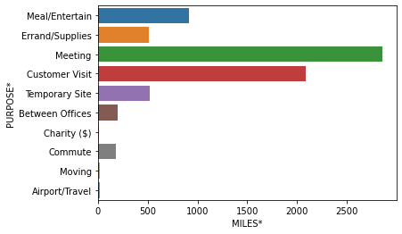

```python
sns.barplot(x='MILES*', y='PURPOSE*', estimator=np.sum, data=uber_drives, ci=None);


#The plot below shows a bar graph between purpose and total miles travelled by people for the purpose.
#From the plot it is clear that the people are travelling via uber drives for the purpose of meeting immediately followed by Customer Visit.
```

## Q20. Display a dataframe of Purpose and the total distance travelled for that particular Purpose. (3 points)

#### Note: Use the original dataframe without dropping "NA" values

```python
df1 = pd.DataFrame(uber_drives['MILES*'].groupby(uber_drives['PURPOSE*']).sum())
df1.reset_index(inplace=True)
df1
```

|  | PURPOSE* | MILES* |
| --- | --- | --- |
| 0 | Airport/Travel | 16.5 |
| 1 | Between Offices | 197.0 |
| 2 | Charity ($) | 15.1 |
| 3 | Commute | 180.2 |
| 4 | Customer Visit | 2089.5 |
| 5 | Errand/Supplies | 508.0 |
| 6 | Meal/Entertain | 911.7 |
| 7 | Meeting | 2851.3 |
| 8 | Moving | 18.2 |
| 9 | Temporary Site | 523.7 |

# Q21. Generate a plot showing count of trips vs category of trips. What can you infer from the plot (2 +1 points)

#### Note: Use the original dataframe without dropping the 'NA' values.

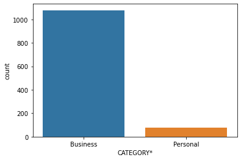

```python
plt.figure(figsize=(6,4))
sns.countplot(uber_drives['CATEGORY*']);

#The below plot shows the count of trips taken by uber users for each categorical bin i.e.,Business and Personal in this case.
#It clearly shows that people travelling for business category takes the upper hand.
```

## Q22. What percentage of Miles were clocked under Business Category and what percentage of Miles were clocked under Personal Category ? (3 points)

### Note:Use the original dataframe without dropping the 'NA' values.

```python
miles_sum=uber_drives['MILES*'].sum()
print('The percentage of miles clocked under Business Category:', round((uber_drives[uber_drives['CATEGORY*']=='Business']['MILES*'].sum() * 100)/miles_sum,2))
print('The percentage of miles clocked under Personal Category:', round((uber_drives[uber_drives['CATEGORY*']=='Personal']['MILES*'].sum() * 100)/miles_sum,2))


#OR
#we can use below method as well to get the percentages. If we have one more category other than business and personal the index value will change and will not work as expected
# df2 = uber_drives.groupby(['CATEGORY*']).sum()
# df2.reset_index(inplace=True)
# percentagelist=np.array([round((df2.iloc[0,1] * 100)/(df2['MILES*'].sum()),2),round((df2.iloc[1,1] * 100)/(df2['MILES*'].sum()),2)])
# df2['MILES_PERCENTAGE'] = percentagelist
# print(df2)
# print('The percentage of miles clocked under Business Category:', round((df2.iloc[0,1] * 100)/(df2['MILES*'].sum()),2))
# print('The percentage of miles clocked under Personal Category:', round((df2.iloc[1,1] * 100)/(df2['MILES*'].sum()),2))
```

```
The percentage of miles clocked under Business Category: 94.12
The percentage of miles clocked under Personal Category: 5.88
```

*THE END*